# Final_Project

Pankaj Gaonkar

2025-04-22

# **ABOUT**

This script is designed for the analysis of the Shotgun_POULTRY microbiome data This script contains the statistical analysis, exploratory plots and publication plots. Each step of the analysis is discussed at my best capabilities.For more detailed understanding (including biological interpretation) please refer the Readme file.

## Readme file link

[Click Here: Readme File](https://github.com/ppg0001/PLPA_Assignment/blob/main/README.md)

*NOTE: This document is for class purpose and is intended to be updated*

# **Getting ready**

## Loading packages

```r
# Loading Packages
# Note: Uncomment and install/load the packages if required

# if(!requireNamespace("BiocManager")){
#   install.packages("BiocManager")
# }
# BiocManager::install("phyloseq")
# BiocManager::install("microViz")
# BiocManager::install("microbiomeMarker")
#
# install.packages("remotes")
# remotes::install_github("david-barnett/microViz")
# library(microViz)
#
# #Install pairwiseAdonis package if not already installed
# if (!requireNamespace("devtools", quietly = TRUE)) {
#   install.packages("devtools")
# }
# devtools::install_github("pmartinezarbizu/pairwiseAdonis/pairwiseAdonis")

# Load the package
# library(pairwiseAdonis)


library(ggplot2)
library(svglite)
library(scales)
library(tibble)
library(reshape2)
library(Polychrome)
library(RColorBrewer)
library(readxl)
library(tidyverse)
library(ggpubr)

library(phyloseq)
library(vegan)
library(microViz)
```

[output not shown]

```r
library(microbiomeMarker)
library(dplyr)
library(tidyr)

library(VennDiagram)
library(grid)
```

## Loading required input files

```r
# Load the microbiome realtive abundance data, sample metadata, taxanomy metadata.
# Note: All files are present in project folder and can be uploaded relatively.

tbl_otu <- read.delim("Microbiome_RelAb.tsv") %>%
  column_to_rownames(var = "Taxon")

mt_smpl <- read.delim("Sample_metadata.tsv",
                      #row.names=1,
                      stringsAsFactors=TRUE) %>%
           #Duplicating sample column for rowname
           mutate(sample = Sample) %>%
           column_to_rownames(var = "sample")

# Reordering factors
# We have two fain groups: Farm types and Sample types. Within main group we have respective subgroups.

mt_smpl$Farm_type <- factor(mt_smpl$Farm_type,
                         levels = c("Pullet", "Breeder", "Broiler", "Processing_plant")
                         )
mt_smpl$Sample_type <- factor(mt_smpl$Sample_type,
                             levels = c("Litter", "Soil")
                             )
#unique command helps to avoid duplicates, arrange levels as per biological relevance, here based on poultry company and poultry production chain

mt_smpl$Sample_group <- factor(mt_smpl$Sample_group,
                               levels = unique(c("C2F4L","C2F4L","C2F4L","C2F1L","C3F10L","C3F14L","C2F4S","C2F4S","C2F4S","C2F1S","C3F10S","C3F14S","C2F4F","C2F4F","C2F4F","C4F17L","C4F17L","C4F17L","C4F8L","C4F17S","C4F17S","C4F17S","C4F8S","C4F17F","C4F17F","C4F17F","C8F40L","C8F40L","C8F40L","C6F35L","C6F37L","C6F60L","C7F14L","C7F22L","C7F81L","C8F40S","C8F40S","C8F40S","C6F35S","C6F37S","C6F60S","C7F14S","C7F22S","C7F81S","C8F40F","C8F40F","C8F40F","C4F8PP","C4F8PC","C12FCHL","C13FJBL","C12FCHS","C13FJBS","C14FJOL","C14FJOS","C15FNSL","C15FTCL","C16FHWL","C17FHEL","C18FCLL","C18FHHL","C18FTGL","C20FJAL","C19FTTL","C20FPHL","C15FNSS","C15FTCS","C16FHWS","C17FHES","C18FCLS","C18FHHS","C18FTGS","C20FJAS","C19FTTS","C20PHS")))


mt_smpl$Sample <- factor(mt_smpl$Sample,
                               levels = c("C2F4L1","C2F4L2","C2F4L3","C2F1L","C3F10L","C3F14L","C2F4S1","C2F4S2","C2F4S3","C2F1S","C3F10S","C3F14S","C2F4F1","C2F4F2","C2F4F3","C4F17L1","C4F17L2","C4F17L3","C4F8L","C4F17S1","C4F17S2","C4F17S3","C4F8S","C4F17F1","C4F17F2","C4F17F3","C8F40L1","C8F40L2","C8F40L3","C6F35L","C6F37L","C6F60L","C7F14L","C7F22L","C7F81L","C8F40S1","C8F40S2","C8F40S3","C6F35S","C6F37S","C6F60S","C7F14S","C7F22S","C7F81S","C8F40F1","C8F40F2","C8F40F3","C4F8PP","C4F8PC","C12FCHL","C13FJBL","C12FCHS","C13FJBS","C14FJOL","C14FJOS","C15FNSL","C15FTCL","C16FHWL","C17FHEL","C18FCLL","C18FHHL","C18FTGL","C20FJAL","C19FTTL","C20FPHL","C15FNSS","C15FTCS","C16FHWS","C17FHES","C18FCLS","C18FHHS","C18FTGS","C20FJAS","C19FTTS","C20PHS"))

# Loading taxonomy metadata file

mt_tax <- read.delim("Taxonomy_metadata.tsv",
                     #row.names=1,
                     stringsAsFactors=TRUE) %>%
          column_to_rownames(var = "Taxon")
```

## Setting colors

It is important to follow a consistent coloring scheme throughout the plots and paper. The color palette for the taxa will be created using the package “Polychrome”.

```r
# Creating color vectors

# Sample colors
col_sample <- c("#D02C2C", "#5BBCD6", "#F2AD00", "#F98400","#00A08A")

# Source colors
col_farm <- c("#E0BD48", "#319dc8", "#735794", "darkgrey" )

col_phy <- c ("#0DFFCA","#DDE996","#FB6CE0","#71BDA3","#FFAE8D","#A90040","#C2C8FE","#72722A","#D1EE0D","#FD89BB","#1CFE1C","#FD00FB","#165A6A","#79351C","#9E00FF","#E8DAD4","#26FAFD","#FF00B1","#FF7E1C","#51B44F","#9B4FA7","#F4C538","#2287E2","#ED3B2E","#1C5CFD","#B684FF","#835D75","#535454")

col_tax <- c("#b2df8a","#f781bf","#a65628","#ffff33","#984ea3","#4daf4a","#ff7f00","#377eb8","#e41a1c","#999999")

# We can use the following as our coloring scheme (uncomment if needed below)
#swatch(col_sample)
#swatch(col_farm)
#swatch(col_tax)
#swatch(col_phy)
```

## Print dataset structure

```r
as_tibble(mt_smpl)
```

```
## # A tibble: 75 × 7
##    Sample Farm_Num Sample_group Farm_type Sample_type Company TotalReads
##    <fct>  <fct>    <fct>        <fct>     <fct>       <fct>        <int>
##  1 C2F1L  FN1      C2F1L        Pullet    Litter      A         78823314
##  2 C2F1S  FN1      C2F1S        Pullet    Soil        A         89536814
##  3 C2F4F1 FN2      C2F4F        Pullet    <NA>        A         41022956
##  4 C2F4F2 FN2      C2F4F        Pullet    <NA>        A         37557920
##  5 C2F4F3 FN2      C2F4F        Pullet    <NA>        A         49042293
##  6 C2F4L1 FN2      C2F4L        Pullet    Litter      A         48994993
##  7 C2F4L2 FN2      C2F4L        Pullet    Litter      A         53297079
##  8 C2F4L3 FN2      C2F4L        Pullet    Litter      A         40989190
##  9 C2F4S1 FN2      C2F4S        Pullet    Soil        A         37288480
## 10 C2F4S2 FN2      C2F4S        Pullet    Soil        A         49869876
## # ℹ 65 more rows
```

```r
#Note the NA values belong to the Fecal samples and Processing plant samples, which are not included in analysis and will not be included in further analysis for this final project.
```

# **Metaphlan and phyloseq**

- Metaphlan outputs a table of relative abundances. However, phyloseq *only accepts absolute abundances for alpha-diversity analysis*.
- In order to use phyloseq the relative abundance data will be coerced into natural counts. This will done by multiplying the relative abundance by the number of mapped reads/sample (included in the table mt_smpl and obtained from metaphlan output), then rounding the table, thus creating a dummy table of natural counts. This table preserves the relative abundances relationships between SGBs and allows phyloseq to run.

## Creating natural count table

```r
#Creating a vector containing the the total number of reads in the same order as the columns in tbl_otu so they match.

nreads <- mt_smpl$TotalReads
#nreads   #Uncomment to see output

#Dividing all values in tbl_otu to shrink proportions to 0-1

tbl_otu <- tbl_otu[,1:ncol(tbl_otu)]/100

#Multiplying all values (x) of column ith (i) by the ith element of the nreads vector (i'), such as i(x)*i' = estimated read count (ecount)

tbl_otu_ecount <- as.data.frame(t(t(tbl_otu)*nreads)) %>%
                  dplyr::mutate(across(is.numeric, round))
#The table is being transposed so that every row (i) matches with the vector entry (i'), then performing the multiplication. After this the table is transposed again to original wide shape. Then the multiplied table is fed into the mutate function which goes across and rounds all of the numerical values.
```

## The count data is ready to be imported into phyloseq

```r
#Importing files to phyloseq

OTUcount = otu_table(tbl_otu_ecount,
                taxa_are_rows = TRUE)
      #Needs to be parsed as matrix.
TAX = tax_table(as.matrix(mt_tax)
                )
      #Needs to be parsed as matrix.
sampledata = sample_data(mt_smpl)

#Creating phyloseq objects
phycount_e = phyloseq(OTUcount, TAX, sampledata)

#Excluding Unclassified, Archaea and Dropping other groups that needs to be excluded
phycount_e <- phycount_e %>%
  subset_taxa(!Phylum == "UNCLASSIFIED") #%>%
```

## Phyloseq summary

```r
phycount_e
```

```
## phyloseq-class experiment-level object
## otu_table()   OTU Table:         [ 3535 taxa and 75 samples ]
## sample_data() Sample Data:       [ 75 samples by 7 sample variables ]
## tax_table()   Taxonomy Table:    [ 3535 taxa by 7 taxonomic ranks ]
```

```r
print("")
```

```
## [1] ""
```

```r
print("Unique Phyla in phycount_e Object")
```

```
## [1] "Unique Phyla in phycount_e Object"
```

```r
get_taxa_unique(phycount_e, "Phylum")
```

```
##  [1] "Firmicutes"                  "Actinobacteria"
##  [3] "Bacteroidetes"               "Proteobacteria"
##  [5] "Euryarchaeota"               "Cyanobacteria"
##  [7] "Bacteria_unclassified"       "Deinococcus_Thermus"
##  [9] "Thaumarchaeota"              "Acidobacteria"
## [11] "Planctomycetes"              "Chloroflexi"
## [13] "Gemmatimonadetes"            "Nitrospirae"
## [15] "Ascomycota"                  "Verrucomicrobia"
## [17] "Candidatus_Thermoplasmatota" "Fusobacteria"
## [19] "Candidatus_Melainabacteria"  "Lentisphaerae"
## [21] "Synergistetes"               "Chlamydiae"
## [23] "Spirochaetes"                "Rhodothermaeota"
## [25] "Deferribacteres"             "Candidatus_Adlerbacteria"
## [27] "Candidatus_Saccharibacteria"
```

```r
print("Sample Sources in phycount_e object")
```

```
## [1] "Sample Sources in phycount_e object"
```

```r
levels(sample_data(phycount_e)$Sample_type)
```

```
## [1] "Litter" "Soil"
```

# **Alpha Diversity**

## Calculating alpha-diversity indexes

```r
phycount_div <- estimate_richness(phycount_e,
                                     split = TRUE,
                                     measures = c("Observed", "Simpson", "Shannon")
                                     )
#Adding sample data to table

phycount_div <- left_join(rownames_to_column(phycount_div, "Sample"),
                             mt_smpl,
                             by = "Sample")

#Calculating average and standard deviation

phycount_div <- phycount_div %>%
  group_by(Sample_group) %>%
  mutate(m_Observed = mean(Observed),
         sd_Observed = sd(Observed),
         m_Shannon = mean(Shannon),
         sd_Shannon = sd(Shannon),
         m_Simpson = mean(Simpson),
         sd_Simpson = sd(Simpson)
         )

phycount_div
```

```
## # A tibble: 75 × 16
## # Groups:   Sample_group [57]
##    Sample  Observed Shannon Simpson Farm_Num Sample_group Farm_type Sample_type
##    <chr>      <dbl>   <dbl>   <dbl> <fct>    <fct>        <fct>     <fct>
##  1 C12FCHL      320    3.85   0.961 FN21     C12FCHL      Pullet    Litter
##  2 C12FCHS      503    5.14   0.990 FN21     C12FCHS      Pullet    Soil
##  3 C13FJBL      219    3.40   0.927 FN22     C13FJBL      Pullet    Litter
##  4 C13FJBS      600    5.06   0.984 FN22     C13FJBS      Pullet    Soil
##  5 C14FJOS      254    3.44   0.893 FN23     C14FJOS      Breeder   Soil
##  6 C14FJOL      557    3.63   0.943 FN23     C14FJOL      Breeder   Litter
##  7 C15FNSL      299    2.91   0.808 FN24     C15FNSL      Breeder   Litter
##  8 C15FNSS      385    4.82   0.986 FN24     C15FNSS      Breeder   Soil
##  9 C15FTCL      398    3.34   0.884 FN25     C15FTCL      Breeder   Litter
## 10 C15FTCS      318    3.40   0.849 FN25     C15FTCS      Breeder   Soil
## # ℹ 65 more rows
## # ℹ 8 more variables: Company <fct>, TotalReads <int>, m_Observed <dbl>,
## #   sd_Observed <dbl>, m_Shannon <dbl>, sd_Shannon <dbl>, m_Simpson <dbl>,
## #   sd_Simpson <dbl>
```

```r
#Write the alpha diversity values for each sample and average the replicates
write.csv(phycount_div, "Phycount_div_each_sample.csv")


## Table for alpha diversity

Alpha_descriptive_stats <- phycount_div %>%
  filter(Sample_type %in% c("Litter", "Soil")) %>%
  group_by(Farm_type, Sample_type) %>%
  summarise(
         m_Observed = mean(Observed),
         sd_Observed = sd(Observed),
         m_Simpson = mean(Simpson),
         sd_Simpson = sd(Simpson),
         m_Shannon = mean(Shannon),
         sd_Shannon = sd(Shannon),

  ) %>%
  ungroup()
# Print the table
print(Alpha_descriptive_stats)
```

```
## # A tibble: 6 × 8
##   Farm_type Sample_type m_Observed sd_Observed m_Simpson sd_Simpson m_Shannon
##   <fct>     <fct>            <dbl>       <dbl>     <dbl>      <dbl>     <dbl>
## 1 Pullet    Litter            140.       105.      0.892    0.0767       2.99
## 2 Pullet    Soil              340.       168.      0.979    0.00657      4.54
## 3 Breeder   Litter            275.       140.      0.901    0.0597       3.22
## 4 Breeder   Soil              320.       152.      0.941    0.0425       4.01
## 5 Broiler   Litter            240.        58.5     0.919    0.0291       3.17
## 6 Broiler   Soil              367.       176.      0.961    0.0190       4.19
## # ℹ 1 more variable: sd_Shannon <dbl>
```

```r
write.csv(Alpha_descriptive_stats, "Alpha_Divertsity_descriptive_stats.csv")
```

## Alpha diversity: t-test comparision between Litter and Soil within each farm types

```r
# Using t.test to compare between the two groups

##Comparing Observed Richness
print("RICHNESS PULLET")
```

```
## [1] "RICHNESS PULLET"
```

```r
phycount_div %>%
  filter(Sample_type %in% c("Soil", "Litter"),
         Farm_type == "Pullet") %>%
  t.test(Observed ~ Sample_type,
       data = .
       )
```

```
##
##  Welch Two Sample t-test
##
## data:  Observed by Sample_type
## t = -2.4673, df = 8.4047, p-value = 0.0375
## alternative hypothesis: true difference in means between group Litter and group Soil is not equal to 0
## 95 percent confidence interval:
##  -384.08631  -14.58035
## sample estimates:
## mean in group Litter   mean in group Soil
##             140.3333             339.6667
```

```r
print("RICHNESS BREEDER")
```

```
## [1] "RICHNESS BREEDER"
```

```r
phycount_div %>%
  filter(Sample_type %in% c("Soil", "Litter"),
         Farm_type == "Breeder") %>%
  t.test(Observed ~ Sample_type,
       data = .
       )
```

```
##
##  Welch Two Sample t-test
##
## data:  Observed by Sample_type
## t = -0.69508, df = 17.885, p-value = 0.4959
## alternative hypothesis: true difference in means between group Litter and group Soil is not equal to 0
## 95 percent confidence interval:
##  -183.08883   92.08883
## sample estimates:
## mean in group Litter   mean in group Soil
##                274.9                320.4
```

```r
print("RICHNESS BROILER")
```

```
## [1] "RICHNESS BROILER"
```

```r
phycount_div %>%
  filter(Sample_type %in% c("Soil", "Litter"),
         Farm_type == "Broiler") %>%
  t.test(Observed ~ Sample_type,
       data = .
       )
```

```
##
##  Welch Two Sample t-test
##
## data:  Observed by Sample_type
## t = -2.7454, df = 18.28, p-value = 0.01317
## alternative hypothesis: true difference in means between group Litter and group Soil is not equal to 0
## 95 percent confidence interval:
##  -224.30191  -29.94809
## sample estimates:
## mean in group Litter   mean in group Soil
##              240.125              367.250
```

```r
##Comparing Shannon index
print("SHANNON PULLET")
```

```
## [1] "SHANNON PULLET"
```

```r
phycount_div %>%
  filter(Sample_type %in% c("Soil", "Litter"),
         Farm_type == "Pullet") %>%
  t.test(Shannon ~ Sample_type,
       data = .
       )
```

```
##
##  Welch Two Sample t-test
##
## data:  Shannon by Sample_type
## t = -5.2641, df = 9.4962, p-value = 0.0004341
## alternative hypothesis: true difference in means between group Litter and group Soil is not equal to 0
## 95 percent confidence interval:
##  -2.2161807 -0.8913371
## sample estimates:
## mean in group Litter   mean in group Soil
##             2.986119             4.539878
```

```r
print("SHANNON BREEDER")
```

```
## [1] "SHANNON BREEDER"
```

```r
phycount_div %>%
  filter(Sample_type %in% c("Soil", "Litter"),
         Farm_type == "Breeder") %>%
  t.test(Shannon ~ Sample_type,
       data = .
       )
```

```
##
##  Welch Two Sample t-test
##
## data:  Shannon by Sample_type
## t = -4.1251, df = 17.863, p-value = 0.0006447
## alternative hypothesis: true difference in means between group Litter and group Soil is not equal to 0
## 95 percent confidence interval:
##  -1.1830222 -0.3843323
## sample estimates:
## mean in group Litter   mean in group Soil
##             3.223258             4.006936
```

```r
print("SHANNON BROILER")
```

```
## [1] "SHANNON BROILER"
```

```r
phycount_div %>%
  filter(Sample_type %in% c("Soil", "Litter"),
         Farm_type == "Broiler") %>%
  t.test(Shannon ~ Sample_type,
       data = .
       )
```

```
##
##  Welch Two Sample t-test
##
## data:  Shannon by Sample_type
## t = -8.0914, df = 19.293, p-value = 1.268e-07
## alternative hypothesis: true difference in means between group Litter and group Soil is not equal to 0
## 95 percent confidence interval:
##  -1.2823304 -0.7556906
## sample estimates:
## mean in group Litter   mean in group Soil
##             3.173157             4.192168
```

```r
##Comparing Simpson index
print("SIMPSON PULLET")
```

```
## [1] "SIMPSON PULLET"
```

```r
phycount_div %>%
  filter(Sample_type %in% c("Soil", "Litter"),
         Farm_type == "Pullet") %>%
  t.test(Simpson ~ Sample_type,
       data = .
       )
```

```
##
##  Welch Two Sample t-test
##
## data:  Simpson by Sample_type
## t = -2.7854, df = 5.0735, p-value = 0.03804
## alternative hypothesis: true difference in means between group Litter and group Soil is not equal to 0
## 95 percent confidence interval:
##  -0.167894531 -0.007098203
## sample estimates:
## mean in group Litter   mean in group Soil
##            0.8919210            0.9794174
```

```r
print("SIMPSON BREEDER")
```

```
## [1] "SIMPSON BREEDER"
```

```r
phycount_div %>%
  filter(Sample_type %in% c("Soil", "Litter"),
         Farm_type == "Breeder") %>%
  t.test(Simpson ~ Sample_type,
       data = .
       )
```

```
##
##  Welch Two Sample t-test
##
## data:  Simpson by Sample_type
## t = -1.7467, df = 16.246, p-value = 0.09957
## alternative hypothesis: true difference in means between group Litter and group Soil is not equal to 0
## 95 percent confidence interval:
##  -0.089546681  0.008589404
## sample estimates:
## mean in group Litter   mean in group Soil
##            0.9007753            0.9412540
```

```r
print("SIMPSON BROILER")
```

```
## [1] "SIMPSON BROILER"
```

```r
phycount_div %>%
  filter(Sample_type %in% c("Soil", "Litter"),
         Farm_type == "Broiler") %>%
  t.test(Observed ~ Sample_type,
       data = .
       )
```

```
##
##  Welch Two Sample t-test
##
## data:  Observed by Sample_type
## t = -2.7454, df = 18.28, p-value = 0.01317
## alternative hypothesis: true difference in means between group Litter and group Soil is not equal to 0
## 95 percent confidence interval:
##  -224.30191  -29.94809
## sample estimates:
## mean in group Litter   mean in group Soil
##              240.125              367.250
```

Writing alpha diversity t-test to file

```r
## Sink command, it print everything between sinks()

set.seed(43)
sink("AlphaDiversity_ttest.txt")

   ##Comparing OBserved Richness
   print("RICHNESS PULLET")
   phycount_div %>%
     filter(Sample_type %in% c("Soil", "Litter"),
            Farm_type == "Pullet") %>%
     t.test(Observed ~ Sample_type,
          data = .
          )
   print("RICHNESS BREEDER")
   phycount_div %>%
     filter(Sample_type %in% c("Soil", "Litter"),
            Farm_type == "Breeder") %>%
     t.test(Observed ~ Sample_type,
          data = .
          )
   print("RICHNESS BROILER")
   phycount_div %>%
     filter(Sample_type %in% c("Soil", "Litter"),
            Farm_type == "Broiler") %>%
     t.test(Observed ~ Sample_type,
          data = .
          )


   ##Comparing Shannon index
   print("SHANNON PULLET")
   phycount_div %>%
     filter(Sample_type %in% c("Soil", "Litter"),
            Farm_type == "Pullet") %>%
     t.test(Shannon ~ Sample_type,
          data = .
          )
   print("SHANNON BREEDER")
   phycount_div %>%
     filter(Sample_type %in% c("Soil", "Litter"),
            Farm_type == "Breeder") %>%
    t.test(Shannon ~ Sample_type,
         data = .
         )
  print("SHANNON BROILER")
  phycount_div %>%
    filter(Sample_type %in% c("Soil", "Litter"),
           Farm_type == "Broiler") %>%
    t.test(Shannon ~ Sample_type,
         data = .
         )

  ##Comparing Simpson index
  print("SIMPSON PULLET")
  phycount_div %>%
    filter(Sample_type %in% c("Soil", "Litter"),
           Farm_type == "Pullet") %>%
    t.test(Simpson ~ Sample_type,
         data = .
         )
  print("SIMPSON BREEDER")
  phycount_div %>%
    filter(Sample_type %in% c("Soil", "Litter"),
           Farm_type == "Breeder") %>%
    t.test(Simpson ~ Sample_type,
         data = .
         )
  print("SIMPSON BROILER")
  phycount_div %>%
    filter(Sample_type %in% c("Soil", "Litter"),
           Farm_type == "Broiler") %>%
    t.test(Observed ~ Sample_type,
         data = .
         )

sink()
```

Drawing Richness and Diversity plots

```r
#Creating vector for comparing samples
 complist <- list(c("Soil", "Litter"))

#Creating vector with new names
 Farm_name <- c("Pullet", "Breeder", "Broiler", "Processing\nPlant")
names(Farm_name) <- c("Pullet", "Breeder", "Broiler", "Processing_plant")

#Drawing Observed Richness plot
bp_rc <-
      phycount_div %>%
  # filter(Sample_type == "Litter" | Sample_type == "Soil") %>%
  filter(Farm_type != "Processing_plant" & Sample_type != "Fecal") %>%
  ggplot(aes(x = Sample_type,
             y = Observed,
             fill = Sample_type
             )
         ) +
  geom_boxplot() +
  ggtitle("Observed Richness") +
  theme_bw() +
  theme(axis.text = element_text(size = 12,
                                 color = "black",
                                 hjust = 0.5
                                   ),
        axis.text.x = element_text(angle = 45,
                                   vjust = 1,
                                   hjust = 1),
        axis.title = element_blank(),
        panel.grid.minor = element_blank(),
        panel.grid.major = element_line(color = "azure2"),
        plot.title = element_text(size = 14, face = "bold"),
        strip.background = element_rect(fill = "transparent",
                                        color = "transparent"),
        strip.text = element_text(size = 12,
                                  face = "bold"
                                  )
        ) +
  stat_compare_means(comparisons = complist,
                     method = "t.test",
                     label = "p.signif",
                     vjust = 1
                     ) +
  scale_fill_manual(values = col_sample) +
  #facet_grid(Farm_type ~ Company,
   facet_grid(Farm_type ~ .,
             labeller = labeller(Farm_type = Farm_name),
             scales = "free",
            #space = "free_x"
             )


#Drawing Shannon diversity index plot
bp_sn <-
    phycount_div %>%
  # filter(Sample_type == "Litter" | Sample_type == "Soil") %>%
  filter(Farm_type != "Processing_plant" & Sample_type != "Fecal") %>%
  ggplot(aes(x = Sample_type,
             y = Shannon,
             fill = Sample_type
             )
         ) +
  geom_boxplot() +
  ggtitle("Shannon Diversity Index") +
  theme_bw() +
  theme(axis.text = element_text(size = 12,
                                 color = "black",
                                 hjust = 0.5
                                   ),
        axis.text.x = element_text(angle = 45,
                                   vjust = 1,
                                   hjust = 1),
        axis.title = element_blank(),
        panel.grid.minor = element_blank(),
        panel.grid.major = element_line(color = "azure2"),
        plot.title = element_text(size = 14, face = "bold"),
        strip.background = element_rect(fill = "transparent",
                                        color = "transparent"),
        strip.text = element_text(size = 12,
                                  face = "bold"
                                  )
        ) +
  stat_compare_means(comparisons = complist,
                     method = "t.test",
                     label = "p.signif",
                     vjust = 1
                     ) +
  scale_fill_manual(values = col_sample) +
  #facet_grid(Farm_type ~ Company,
  facet_grid(Farm_type ~ .,
             labeller = labeller(Farm_type = Farm_name),
             scales = "free",
            space = "free_x"
             )


#Drawing Simpson diversity index plot
bp_sp <-
  phycount_div %>%
  # filter(Sample_type == "Litter" | Sample_type == "Soil") %>%
  filter(Farm_type != "Processing_plant" & Sample_type != "Fecal") %>%
  ggplot(aes(x = Sample_type,
             y = Simpson,
             fill = Sample_type
                    )
                ) +
  geom_boxplot() +
  ggtitle("Simpson Diversity Index") +
  theme_bw() +
  theme(axis.text = element_text(size = 12,
                                 color = "black",
                                 hjust = 0.5
                                   ),
        axis.text.x = element_text(angle = 45,
                                   vjust = 1,
                                   hjust = 1),
        axis.title = element_blank(),
        panel.grid.minor = element_blank(),
        panel.grid.major = element_line(color = "azure2"),
        plot.title = element_text(size = 14, face = "bold"),
        strip.background = element_rect(fill = "transparent",
                                        color = "transparent"),
        strip.text = element_text(size = 12,
                                  face = "bold"
                                  )
        ) +
  stat_compare_means(comparisons = complist,
                     method = "t.test",
                     label = "p.signif",
                     vjust = 1
                     ) +
  scale_fill_manual(values = col_sample) +
  #facet_grid(Farm_type ~ Company,
  facet_grid(Farm_type ~ .,
             labeller = labeller(Farm_type = Farm_name),
             scales = "free",
            space = "free_x"
             )
```

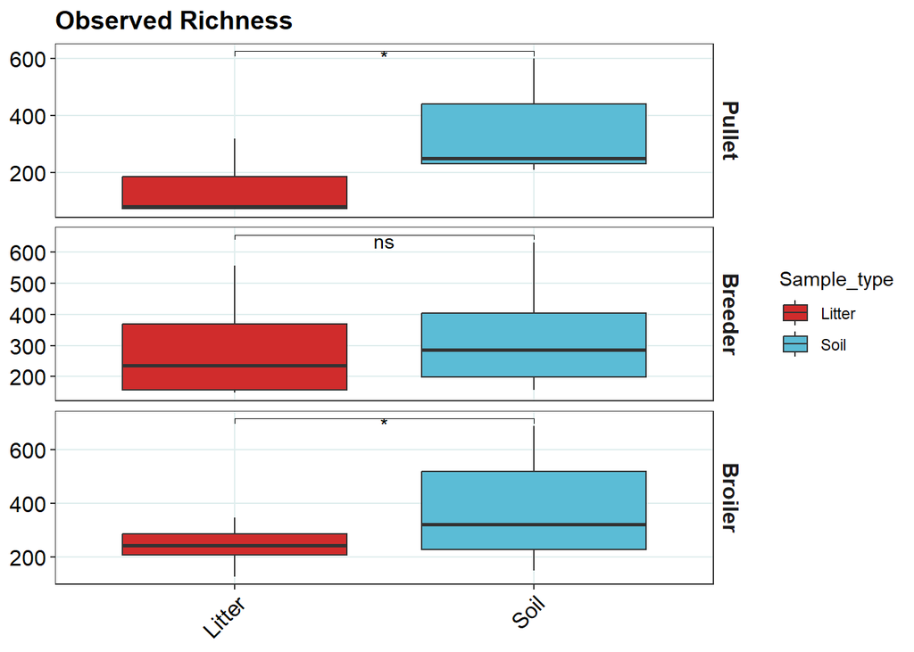

```r
bp_rc
```

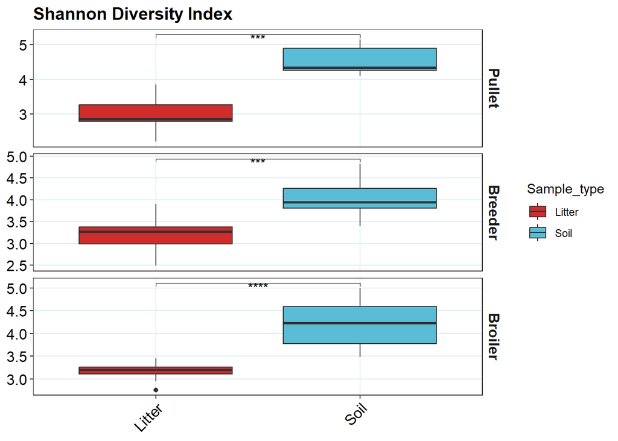

```r
bp_sn
```

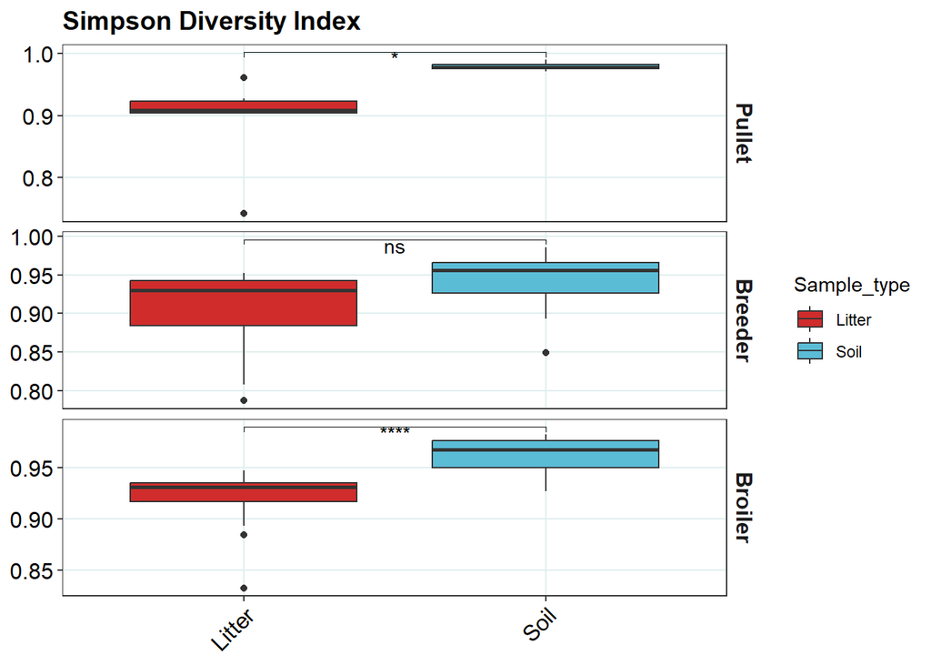

```r
bp_sp
```

Saving combined alpha diversity plots

```r
#Saving plots

#Combined plots
combined_plot_Alpha_Diversity <- ggarrange(bp_rc, bp_sn, bp_sp,
                           ncol = 3,
                           nrow = 1,
                           common.legend = TRUE
)


#Saving plots
ggsave(filename = "Alpha_Diversity_Plots.svg",
       plot = combined_plot_Alpha_Diversity,
       device = "svg",
       units = "mm",
       width = 300,
       height = 250)
```

## Alpha diversity result explanation:

In our study, observed richness and Simpson diversity index were higher in the soil during the pullet and broiler stages, whereas no significant differences were found between litter and soil in the breeder stage. Moreover, the Shannon diversity index was higher in soil samples than in litter across all production stages. These findings indicate that soil contains a more diverse and evenly distributed microbiome, whereas litter is a more selective environment with limited microbes that make up its composition.

# **Exploring the microbial community**

## Lets check which phylum are overall present in our dataset

```r
table(tax_table(phycount_e)[,"Phylum"])
```

```
##
##               Acidobacteria              Actinobacteria
##                          10                         964
##                  Ascomycota       Bacteria_unclassified
##                           3                           2
##               Bacteroidetes    Candidatus_Adlerbacteria
##                         398                           1
##  Candidatus_Melainabacteria Candidatus_Saccharibacteria
##                           6                           2
## Candidatus_Thermoplasmatota                  Chlamydiae
##                           3                           4
##                 Chloroflexi               Cyanobacteria
##                           6                          54
##             Deferribacteres         Deinococcus_Thermus
##                           1                          21
##               Euryarchaeota                  Firmicutes
##                          15                         742
##                Fusobacteria            Gemmatimonadetes
##                           2                           2
##               Lentisphaerae                 Nitrospirae
##                           4                           4
##              Planctomycetes              Proteobacteria
##                          20                        1246
##             Rhodothermaeota                Spirochaetes
##                           1                           3
##               Synergistetes              Thaumarchaeota
##                           1                           8
##             Verrucomicrobia
##                          12
```

## Microbial community bar plots

First step in visualizing the community structure. In order to create the barplots, the data needs to be transformed from wide to long. This will also allow all the metadata to be incorporated into the table

```r
#Melting table

tbl_mstr_pc <- melt(rownames_to_column(tbl_otu, var = "Taxon"),
                 id.vars = c("Taxon"),
                 variable.name = "Sample",
                 value.name = "Count") %>%
#Adding Metadata
            left_join(mt_smpl,
                      by = "Sample") %>%
            left_join(rownames_to_column(mt_tax, var = "Taxon"),
                      by = "Taxon")
```

Re-ordering factors so that the main colors of the swatch correspond to the most abundant phyla across:

```r
#Summarizing counts by phyla

tbl_mstr_pc %>%
  group_by(Phylum) %>%
  summarise(Count = sum(Count)) %>%
  arrange(Count) %>%
  select(Phylum) %>%
  ungroup()
```

```
## # A tibble: 28 × 1
##    Phylum
##    <fct>
##  1 Deferribacteres
##  2 Rhodothermaeota
##  3 Candidatus_Adlerbacteria
##  4 Candidatus_Saccharibacteria
##  5 Lentisphaerae
##  6 Spirochaetes
##  7 Ascomycota
##  8 Chlamydiae
##  9 Synergistetes
## 10 Verrucomicrobia
## # ℹ 18 more rows
```

```r
#Reordering factors in Phylum column according to most abundant.
#NOTE: Phyla will be reordered in ascending order (from least to most). This allows us to drop some levels (ex: Unclassified), without changing the color key for the other levels

tbl_mstr_pc$Phylum <- factor(tbl_mstr_pc$Phylum,
                          levels = c("Deferribacteres","Rhodothermaeota","Candidatus_Adlerbacteria","Candidatus_Saccharibacteria","Lentisphaerae","Spirochaetes","Chlamydiae","Synergistetes","Verrucomicrobia","Candidatus_Thermoplasmatota","Gemmatimonadetes","Nitrospirae","Candidatus_Melainabacteria","Bacteria_unclassified","Fusobacteria","Acidobacteria","Planctomycetes","Chloroflexi","Deinococcus_Thermus","Cyanobacteria","Bacteroidetes","Proteobacteria","Actinobacteria","Firmicutes","Ascomycota","Thaumarchaeota","Euryarchaeota","UNCLASSIFIED"))
```

Creating summarised table for barplots

```r
tbl_mstr_bp <- tbl_mstr_pc %>%
  group_by(Sample, Phylum) %>%
  summarise(Count = sum(Count)
            ) %>%
  left_join(mt_smpl, by = "Sample") %>%
  distinct() %>%
  droplevels() %>%
  ungroup
```

creating averaged table

```r
# Averaging taxons by Sample_group

tbl_mstr_av <- tbl_mstr_pc %>%
  group_by(Taxon, Sample_group) %>%
  summarise(Count = mean(Count)) %>%
  left_join(select(mt_smpl, !c(Sample, TotalReads)), by = "Sample_group") %>%
  left_join(rownames_to_column(mt_tax, var = "Taxon"), by = "Taxon") %>%
  distinct() %>%
  droplevels() %>%
  ungroup()
##Summarising by Phylum count

tbl_mstr_av_bp <- tbl_mstr_av %>%
  group_by(Phylum, Sample_group) %>%
  summarise(Count = sum(Count)) %>%
  left_join(select(mt_smpl, !c(Sample, TotalReads)), by = "Sample_group") %>%
  distinct() %>%
  droplevels() %>%
  ungroup()
#Reordering Phylum factors (left join brought in factors with disordered levels)

tbl_mstr_av$Phylum <- factor(tbl_mstr_av$Phylum,
                          levels = c("Deferribacteres","Rhodothermaeota","Candidatus_Adlerbacteria","Candidatus_Saccharibacteria","Lentisphaerae","Spirochaetes","Chlamydiae","Synergistetes","Verrucomicrobia","Candidatus_Thermoplasmatota","Gemmatimonadetes","Nitrospirae","Candidatus_Melainabacteria","Bacteria_unclassified","Fusobacteria","Acidobacteria","Planctomycetes","Chloroflexi","Deinococcus_Thermus","Cyanobacteria","Bacteroidetes","Proteobacteria","Actinobacteria","Firmicutes","Ascomycota","Thaumarchaeota","Euryarchaeota","UNCLASSIFIED"))




tbl_mstr_av_bp$Phylum <- factor(tbl_mstr_av_bp$Phylum,
                           levels = c("Deferribacteres","Rhodothermaeota","Candidatus_Adlerbacteria","Candidatus_Saccharibacteria","Lentisphaerae","Spirochaetes","Chlamydiae","Synergistetes","Verrucomicrobia","Candidatus_Thermoplasmatota","Gemmatimonadetes","Nitrospirae","Candidatus_Melainabacteria","Bacteria_unclassified","Fusobacteria","Acidobacteria","Planctomycetes","Chloroflexi","Deinococcus_Thermus","Cyanobacteria","Bacteroidetes","Proteobacteria","Actinobacteria","Firmicutes","Ascomycota","Thaumarchaeota","Euryarchaeota","UNCLASSIFIED"))
```

Drawing AVERAGED microbiome bar plots

```r
####Litter bacterial

relbp_av_bac_Litter <-
tbl_mstr_av_bp %>%
  subset(Phylum!="UNCLASSIFIED" & Phylum!="Thaumarchaeota" & Phylum!= "Euryarchaeota" & Phylum!= "Ascomycota" & Sample_type == "Litter"  & Farm_type != "Processing_plant") %>%
  ggplot(aes(x = Sample_group,
             y = Count,
             fill = Phylum
             )
         ) +
  geom_bar(position="fill", stat= "identity") +
  scale_y_continuous(labels = percent) +
  scale_fill_manual(values = col_phy) +
  theme_bw() +
  labs(title = "Microbiome Composition - Bacterial") +
  ylab("Relative Abundance") +
  theme_bw() +
  theme(axis.text = element_text(size = 12,
                                 color = "black"),
        axis.text.x = element_text(hjust = 1,
                                 vjust = 0.5,
                                 angle = 90),
        axis.title = element_blank(),
        panel.grid.minor = element_blank(),
        panel.grid.major = element_line(color = "azure2"),
        plot.title = element_text(hjust = 0.5, size = 14, face = "bold"),
        strip.background = element_rect(fill = "transparent",
                                        color = "transparent"),
        strip.text = element_text(size = 12,
                                  face = "bold"
                                  )
        ) +
  facet_grid(Sample_type ~ Farm_type, scale = "free_x", space = "free_x")



####Soil bacterial

relbp_av_bac_Soil <-
tbl_mstr_av_bp %>%
  subset(Phylum!="UNCLASSIFIED" & Phylum!="Thaumarchaeota" & Phylum!= "Euryarchaeota" & Phylum!= "Ascomycota" & Sample_type == "Soil"  & Farm_type != "Processing_plant") %>%
  ggplot(aes(x = Sample_group,
             y = Count,
             fill = Phylum
             )
         ) +
  geom_bar(position="fill", stat= "identity") +
  scale_y_continuous(labels = percent) +
  scale_fill_manual(values = col_phy) +
  theme_bw() +
  ylab("Relative Abundance") +
  theme_bw() +
  theme(axis.text = element_text(size = 12,
                                 color = "black"),
        axis.text.x = element_text(hjust = 1,
                                 vjust = 0.5,
                                 angle = 90),
        axis.title = element_blank(),
        panel.grid.minor = element_blank(),
        panel.grid.major = element_line(color = "azure2"),
        strip.background = element_rect(fill = "transparent",
                                        color = "transparent"),
        strip.text = element_text(size = 12,
                                  face = "bold"
                                  )
        ) +
  facet_grid(Sample_type ~ Farm_type, scale = "free_x", space = "free_x")
```

```r
# Uncomment to see the plot during R analysis
#relbp_av_bac_Litter
#relbp_av_bac_Soil
```

Saving combined relative abundance plots **Note: Please look the saved file to have better visualization of microbiome plot** [Click Here: Figure Microbiome Profile - Phylum](https://github.com/ppg0001/PLPA_Assignment/blob/main/Final_Project/Relative_abundance_Plots.svg)

[figure not shown]

```r
#Saving plots

#Combined plots
combined_plot_relative_abundance_bacteria <- ggarrange(relbp_av_bac_Litter, relbp_av_bac_Soil,
                           ncol = 1,
                           nrow = 2,
                           common.legend = TRUE,
                           legend = "right")

combined_plot_relative_abundance_bacteria
```

```r
#Saving plots
ggsave(filename = "Relative_abundance_Plots.svg",
       plot = combined_plot_relative_abundance_bacteria,
       device = "svg",
       units = "mm",
       width = 350,
       height = 220)
```

# **Exploring Beta-Diversity**

If alpha-diversity is the diversity *within* a community, beta-diversity is the diversity across communities. In beta-diversity we are concerned with comparing and contrasting different profiles.

Communities can be statistically compared by producing distance matrices. On compositional data we will use robust Aitchison distances, which relies on the centered log ratio transform. Once these distances are calculated, profiles can be statistically compared using PERMANOVA and visualized using ordination plots, such as PCoA or PCA.

Creating relative abundance phyloseq object

```r
OTUcount = otu_table(tbl_otu,
                taxa_are_rows = TRUE)
      #Needs to be parsed as matrix.
TAX = tax_table(as.matrix(mt_tax)
                )
      #Needs to be parsed as matrix.
sampledata = sample_data(mt_smpl)

#Creating phyloseq objects
phycount = phyloseq(OTUcount, TAX, sampledata)


#Excluding Unclassified, Archaea and Dropping incomplete sample groups: Larvae and Pollen
phycount <- phycount %>%
  subset_taxa(!Phylum == "UNCLASSIFIED" & !Kingdom == "Archaea" & !Kingdom == "Eukaryota") %>%
  subset_samples(!Sample_type == "Fecal" & !Farm_type == "Processing_plant")
```

```r
# printing phyloseq summary

phycount
```

```
## phyloseq-class experiment-level object
## otu_table()   OTU Table:         [ 3506 taxa and 64 samples ]
## sample_data() Sample Data:       [ 64 samples by 7 sample variables ]
## tax_table()   Taxonomy Table:    [ 3506 taxa by 7 taxonomic ranks ]
```

```r
print("")
```

```
## [1] ""
```

```r
print("Unique Phyla in phycount Object")
```

```
## [1] "Unique Phyla in phycount Object"
```

```r
get_taxa_unique(phycount, "Phylum")
```

```
##  [1] "Firmicutes"                  "Actinobacteria"
##  [3] "Bacteroidetes"               "Proteobacteria"
##  [5] "Cyanobacteria"               "Bacteria_unclassified"
##  [7] "Deinococcus_Thermus"         "Acidobacteria"
##  [9] "Planctomycetes"              "Chloroflexi"
## [11] "Gemmatimonadetes"            "Nitrospirae"
## [13] "Verrucomicrobia"             "Fusobacteria"
## [15] "Candidatus_Melainabacteria"  "Lentisphaerae"
## [17] "Synergistetes"               "Chlamydiae"
## [19] "Spirochaetes"                "Rhodothermaeota"
## [21] "Deferribacteres"             "Candidatus_Adlerbacteria"
## [23] "Candidatus_Saccharibacteria"
```

```r
print("Sample Sources in phycount object")
```

```
## [1] "Sample Sources in phycount object"
```

```r
levels(sample_data(phycount)$Sample_type)
```

```
## [1] "Litter" "Soil"
```

```r
levels(sample_data(phycount)$Farm_type)
```

```
## [1] "Pullet"  "Breeder" "Broiler"
```

## Performing PERMANOVA

- PERMANOVA, (permutational multivariate ANOVA), is a non-parametric alternative to MANOVA, or multivariate ANOVA test.
- PERMANOVAS are calculated using the adonis functions in the package Vegan. To use Vegan, phyloseq objects need to be turned into Vegan objects.
- Next functions convert physeq format into Vegan.

creating pssd2veg function

```r
pssd2veg <- function(physeq) {
  sd <- sample_data(physeq)
  return(as(sd,"data.frame"))
}
```

Creating psotu2veg function

```r
psotu2veg <- function(physeq) {
  OTU <- otu_table(physeq)
  if (taxa_are_rows(OTU)) {
    OTU <- t(OTU)
  }
  return(as(OTU, "matrix"))
}
```

Importing Phyloseq data into teh package Vegan

```r
vegan_count <- pssd2veg(phycount)
vegan_otu <- psotu2veg(phycount)
```

Calculating distance matrix

```r
##Calculating distance matrix using Robust Aitchinson (Euclidean distance of the CLR transform of non-zero values)
veg_count_raitch <- vegdist(vegan_otu, "robust.aitchison")
```

## Running PERMANOVA

```r
#Writing the overall PERMANOVA results in text file
sink("PERMANOVA_Overall_Results.txt")


set.seed(43)

print("Comparing profiles by PERMANOVA",quote = FALSE, justify = "centre")
print("Grouping by Sample_group (Sample_type*Farm_type*Company",quote = FALSE, justify = "centre")

adonis2(veg_count_raitch ~ Sample_type*Farm_type*Company, data = vegan_count, permutations = 999)
print("",quote = FALSE, justify = "centre")
print("Grouping by Sample_type",quote = FALSE, justify = "centre")

adonis2(veg_count_raitch ~ Sample_type, data = vegan_count, permutations = 999)
print("",quote = FALSE, justify = "centre")
print("Grouping by Farm_type",quote = FALSE, justify = "centre")

adonis2(veg_count_raitch ~ Farm_type, data = vegan_count, permutations = 999)
print("",quote = FALSE, justify = "centre")
print("Grouping by Company",quote = FALSE, justify = "centre")

adonis2(veg_count_raitch ~ Company, data = vegan_count, permutations = 999)

sink()
```

Specific adonis pariwise comparision

```r
#Writing the specific pariwise comparission of interest in text file
sink("specific_Pairwise_Comparissions_PERMANOVA.txt")

## Install pairwiseAdonis package if not already installed
#if (!requireNamespace("devtools", quietly = TRUE)) {
# install.packages("devtools")
#}
#devtools::install_github("pmartinezarbizu/pairwiseAdonis/pairwiseAdonis")

# Load the package
library(pairwiseAdonis)
# Perform pairwise PERMANOVA for Sample_type
pairwise.adonis2(veg_count_raitch ~ Sample_type, data = vegan_count, permutations = 999)

# Perform pairwise PERMANOVA for Farm_type
pairwise.adonis2(veg_count_raitch ~ Farm_type, data = vegan_count, permutations = 999)


sink()
```

### ORDINATION WITH PCOA

```r
#Sample type
pcoa_sp_clr_S <-
  phycount %>%
 tax_transform(rank = "Species",
               trans = "identity") %>%
 dist_calc(dist = "robust.aitchison") %>%
 ord_calc(method = "PCoA") %>%
 ord_plot(axes = c(1, 2),
          plot_taxa = 1:3,
          colour = "black",
          fill = "Sample_type",
          shape = "Farm_type",
          alpha = 0.8,
          size = 5
          ) +
  stat_ellipse(aes(colour = Sample_type), linewidth = 0.3) +
  scale_shape_girafe_filled() +
  ggtitle("PCoA Plot: Beta Diversity - Sample Types") +
   guides(fill = guide_legend(override.aes=list(shape = 21)),
          color = FALSE) +
  scale_fill_manual(values = col_sample) +
  # scale_color_manual(values = col_sample) +
  # scale_alpha_discrete(range = c(0.35, 1)) +
  theme_linedraw() +
  theme(panel.grid = element_blank(),
        panel.background = element_rect(fill = "#fdfdfd"),
        axis.text = element_text(size = 14,
                                 color = "black"),
        axis.title = element_text(size = 16,
                                  color = "black")) +
  geom_text(x = 2.5,
            y = -3.4,
            hjust =0,
            vjust = 1,
            label="Sample Type:\nPERMANOVA=0.001",
            size = 3.5,
            fontface = "plain")
#Farm type
pcoa_sp_clr_farm <-
  phycount %>%
 tax_transform(rank = "Species",
               trans = "identity") %>%
 dist_calc(dist = "robust.aitchison") %>%
 ord_calc(method = "PCoA") %>%
 ord_plot(axes = c(1, 2),
          plot_taxa = 1:3,
          colour = "black",
          fill = "Farm_type",
          shape = "Sample_type",
          alpha = 0.8,
          size = 5
          ) +
  stat_ellipse(aes(colour = Farm_type), linewidth = 0.3) +
  scale_shape_girafe_filled() +
  ggtitle("PCoA Plot: Beta Diversity - Farm Types") +
   guides(fill = guide_legend(override.aes=list(shape = 21)),
          color = FALSE) +
  scale_fill_manual(values = col_farm) +
  scale_color_manual(values = col_farm) +
  # scale_alpha_discrete(range = c(0.35, 1)) +
  theme_linedraw() +
  theme(panel.grid = element_blank(),
        panel.background = element_rect(fill = "#fdfdfd"),
        axis.text = element_text(size = 14,
                                 color = "black"),
        axis.title = element_text(size = 16,
                                  color = "black")) +
  geom_text(x = 2.5,
            y = -3.4,
            hjust =0,
            vjust = 1,
            label="Farm Type:\nPERMANOVA=0.001",
            size = 3.5,
            fontface = "plain") #+
  #facet_grid(. ~ Company, scale = "free")
```

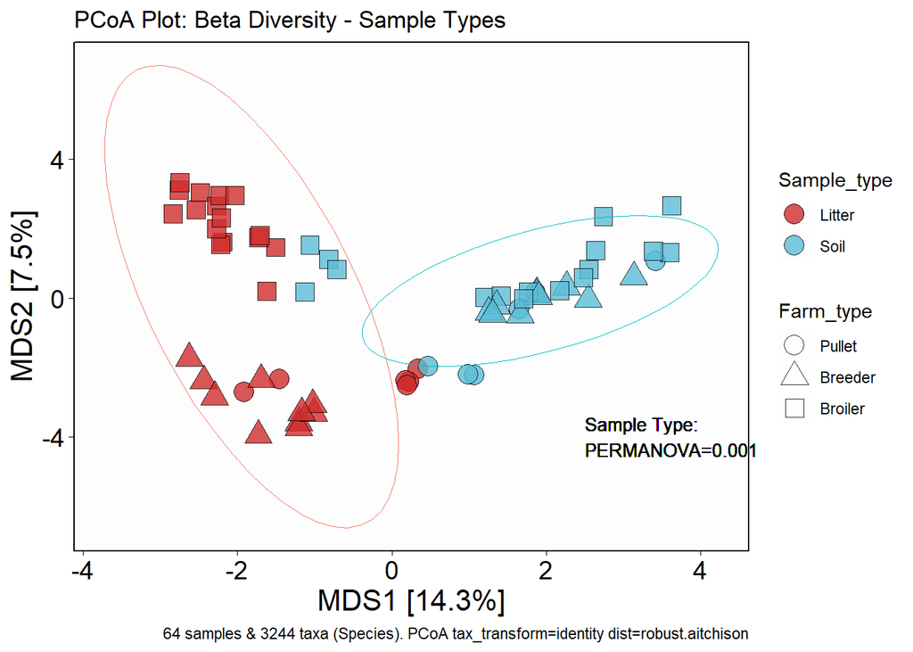

```r
pcoa_sp_clr_S
```

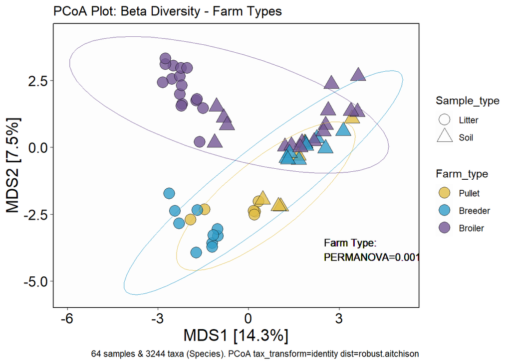

```r
pcoa_sp_clr_farm
```

Saving combined beta diversity - PCoA plots

```r
#Combined plots
combined_PCoA <- ggarrange(pcoa_sp_clr_S, pcoa_sp_clr_farm,
                           ncol = 1,
                           nrow = 2)


ggsave(filename = "Combined_PCoA_plots_betadiversity.svg",
        plot = combined_PCoA,
        device = "svg",
        units = "mm",
        width = 250,
        height = 300)
```

# **Important links**

## A clickable link to GitHub repository

[Click here to visit the GitHub Repository](https://github.com/ppg0001/PLPA_Assignment)

## A clickable link to GitHub flavored .md file

[Click here to go to GitHub flavored .md file](https://github.com/ppg0001/PLPA_Assignment/blob/main/Final_Project/Final_Project_Pankaj.md)

## A clickable link to R codes

[Click here to go to Analysis/R codes(.Rmd file)](https://github.com/ppg0001/PLPA_Assignment/blob/main/Final_Project/Final_Project_Pankaj.Rmd)

## Note: Zenod hasnt been created yet because this data is yet to be published.